# 2022_Lab2_SubThr_10_Pascal_Mueller

Neuromorphic engineering I

## Lab 3: Subthreshold Behavior of Transistors

Group number: 10

Team member 1: Pascal Dominic Müller

Team member 2: Sufyan <don't know the last name sorry>

Date: 10.10.2022

In this lab exercise we will be investigating the subthreshold (weak inversion) behavior of isolated *p*-- and *n*--channel MOSFETs. Specifically, we will

- measure the currents through the transistors as a function of their gate and source voltages
- determine how effective these terminals are at changing the current
- compare the characteristics of p and n-fet devices.

# 1. Prelab

Make sure you have studied the lecture material before attempting this prelab. The questions will also make much more sense if you read through the entire lab handout first. *You are required to complete this prelab before you can begin taking data.*

## 1.1 n- and p-fets, in an *n* well Process

A vertical section through the silicon with both n and p-fet transistors is shown in Figure 1. The class chip has a p-type substrate (like almost all chips nowadays) and both p- and n-wells.  
The p-wells (not shown in the figure) are shorted to the p-substrate because the doping is of the same type.

Because we are grounding the substrate and we are connecting *n*--well to the power supply, $V_{dd}$ is positive. This positive voltage reverse biases the junction between the *n*--wells (which are tied to $V_{dd}$) and the substrate (which is tied to gnd).

For this process, $V_{dd}$=1.8 V.

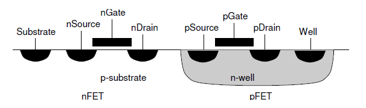

#### Figure 1: a cross section through p-substrate chip.

For the following questions assume an *n*--well process -- unless stated otherwise.

**1.** Draw four-terminal symbols for native and well transistors and label all the terminals; use *d* for drain, *s* for source, *g* for gate, *b* for bulk, and *w* for well. Indicate the direction of current flow that is consistent with your choice of drain and source (you can drag the * .png file into the cell below).

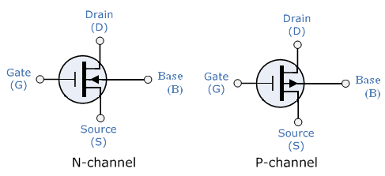

Taken from: https://analyseameter.com/2016/02/field-effect-transistor-types-operation.html

**2.** Write the expressions for the subthreshold (weak inversion) current $I_{ds}$ for both types of transistors.

Slide 54 gives us the equation for subthreshold **nFET**

$$ I = I_0 e^{\kappa V_g/U_T}(e^{-V_s/U_T} - e^{-V_d/U_T}) = I_f - I_r \tag{1} $$

Slide 65 gives us the equation for subthreshold **pFET**

$$ I = I_0 e^{-\kappa V_g/U_T}(e^{V_s/U_T} - e^{V_d/U_T}) = I_f - I_r \tag{2} $$

**3.** Write the expressions for the *saturation* current of these transistors, that is, the value of the current when $V_{ds}\gg\frac{4kT}{q}$. For the remaining questions you may assume that the transistor is in saturation.

From slide 59 we get it for **nFET**

$$ I = I_f = I_0 e^{\kappa V_g - V_s} \tag{3} $$

From slide 66 we get it for **pFET**

$$ I = I_f = I_0 e^{-\kappa V_g + V_s} \tag{4} $$

**4.** For both transistors, write an expression for source voltage as a function of gate voltage if the channel current is constant and the transistor is in saturation. In each case, what is $\frac{\mathrm{d}V_s}{\mathrm{d}V_g}$?

Using (1) to (4) we get

For **nFET:** $$ V_s = \kappa V_g - \ln{\frac{I_{ds}}{I_0}} = \kappa V_g + \ln\frac{I_0}{I_{ds}} \tag{5}$$

For **pFET:** $$ V_s = \kappa V_g + \ln{\frac{I_{ds}}{I_0}} \tag{6} $$

## 1.2 ESD protection of CMOS Chips (need to know)

All MOSFET chips are *extremely* prone to damage by static electricity. The current through the transistors is controlled by an insulated gate.

Not so fun facts: **Even a few tens of volts can blow up the gate. A short walk across the room can build up kilovolts of static potential.**

There are electrostatic discharge (ESD) protection structures on the chip inputs that are designed to leak off the static charge before it can damage the chip, but often this will not be enough.

There are two simple precautions that can definitely keep the chip safe.

**1. When the chip is not powered up in a socket, keep it stuck into a piece of black conductive foam.** This will short all the pins together.

**2. Always ground yourself to chassis (potbox) ground before picking up or touching a chip.** This will discharge the static charge.

## 1.3 Experiments and Lab Reports

For the following experiments, include in your lab reports, graphs of all theoretical and experimental curves. Experimental data should be plotted in a point style so that individual data points are visible. Make sure you take enough data points and label your axes. The theoretical fit should be graphed on the same plot in a line style.

Your written interpretation of the results and any anomalies are essential. Please do not just hand in the plots without any interpretation on your part. Your report does not need to be beautiful, but it should show that you understand what you are measuring.

Remember that the purpose of this lab is to investigate *subthreshold* transistor characteristics. Therefore, all voltage sweeps should span the measurable subthreshold regime while extending just far enough above threshold to show where the threshold is.

Avoid these common mistakes in your report:

- **Not discussing your data sufficiently.** Think about a publication. The readers want to understand your reasoning with you. They want to be able to reproduce your results.
- **Not using cross-hair axes when 0,0 is relevant.** Use grid on to turn on grid, which will draw dotted lines from major ticks. See fontsize to make spacing readable.
- **Forgetting to mention what your plot shows.**
- **Not labeling your figures with a caption,** e.g., “Fig. 1: Transistor drain current vs. gate voltage, Experiment 1.”
- **Insufficiently annotating your data.** It's OK to draw on your plots to indicate the slope of the curve, or the x / y intercepts.
- **Using identical markers for all plots.** Your curves must be distinguishable when printed in black and white. Use e.g. plot(v,i,'o-',v,i2,'s-'), which labels one curve with circle markers and the other with square markers.
- **Forgetting units on measurements,** e.g. “our conductance is 1.000653e-10”. What are the units?
- **Giving your measurements too many digits of precision;** see previous error. Do your instruments really give you 7 digits of precision?

# 2 Set up the experiment

## 2.1 Connect the device

```python
# import the necessary library to communicate with the hardware
import pyplane
import time
import numpy as np
import matplotlib.pyplot as plt
```

```python
# create a Plane object and open the communication
if 'p' not in locals():
    p = pyplane.Plane()
    try:
        p.open('/dev/ttyACM0') # Open the USB device ttyACM0 (the board).
    except RuntimeError as e:
        print(e)

# Note that if you plug out and plug in the USB device in a short time interval, the operating system might allocate a new name like ttyACM1,
# then you may get error messages with open(...ttyACM0). So please avoid frenquently plugging in/out the board.
```

```python
p.get_firmware_version()
```

```
(1, 8, 6)
```

```python
# Send a reset signal to the board, check if the LED blinks
p.reset(pyplane.ResetType.Soft)

time.sleep(1)
# NOTE: You must send this request events every time you do a reset operetion, otherwise the recieved data is noisy.
# Because the class chip need to do handshake to get the communication correct.
p.request_events(1)
```

```python
# Try to read something, make sure the chip responses
p.read_current(pyplane.AdcChannel.GO0_N)
```

```
1.530761721824092e-07
```

```python
# If any of the above steps fail, delete the object, and restart the kernel

# del p
```

## 2.2 Recommendations to this lab

- You do not need to follow the order, it is actually better to do all the measurement of one device together, e.g. 3.1 -> 4.1 -> 3.2 -> 4.2
- **Please save the data as frequent as possible and use the loaded data for processing**

# 3 Current as a Function of Gate Voltage

## 3.1 N-FET

For the N-FET device on the CoACH chip, measure current $I_{ds}$ as a function of gate voltage $V_g$ for fixed source, bulk (substrate or well), and drain voltages.

```python
# uses schemdraw, you may have to install it in order to run it on your PC
import schemdraw
import schemdraw.elements as elm
d = schemdraw.Drawing()
Q = d.add(elm.NFet, reverse=True)
d.add(elm.Dot, xy=Q.gate, lftlabel='gate=AIN0')
d.add(elm.Dot, xy=Q.drain, toplabel='drain=GO22')
d.add(elm.Dot, xy=Q.source, botlabel='source=GO20')
d.draw()
```

[output not shown]

Hint: To cancel out the leakage current and shunt resistance (recall lab1), you may want to do a subtraction

$I_{ds} = I_{GO20} - I_{GO20}|_{V_g = 0}$

- You have to set the input voltage demultiplexer by sending a configuration event:

```python
events = [pyplane.Coach.generate_aerc_event( \
    pyplane.Coach.CurrentOutputSelect.SelectLine5, \
    pyplane.Coach.VoltageOutputSelect.NoneSelected, \
    pyplane.Coach.VoltageInputSelect.SelectLine2, \
    pyplane.Coach.SynapseSelect.NoneSelected, 0)]

p.send_coach_events(events)
```

**Make sure the chip receives the event by a blink of LED1, if it's not the case, the chip is dead and you must replug it.**

- What will be the fixed value for source, bulk (substrate or well), and drain voltages?

$V_s$ = 0.0 V

$V_d$ = 1.0 V

$V_g$ = 0.7 V

```python
# set source voltage
vs_n = 0.0
p.set_voltage(pyplane.DacChannel.GO20,vs_n)
print("The source voltage is set to {} V".format(vs_n))
```

```
The source voltage is set to 0.0 V
```

```python
# set drain voltage
vd_n = 1.0
p.set_voltage(pyplane.DacChannel.GO22, vd_n)
print("The drain voltage is set to {} V".format(vd_n))
```

```
The drain voltage is set to 1.0 V
```

```python
# set trial gate voltage
vg_n = 0.7
p.set_voltage(pyplane.DacChannel.AIN0, vg_n)
print("The trial gate voltage is set to {} V".format(vg_n))
```

```
The trial gate voltage is set to 0.7 V
```

```python
# read Ids, from *Source* --> NOTE THAT THE ADC CHANNEL PIN CHANGES THE NAME FOR THE SOURCE
ids_n = p.read_current(pyplane.AdcChannel.GO20_N)
print("Ids is {} A".format(ids_n))
```

```
Ids is 9.99023427539214e-07 A
```

- Data aquisition

```python
# Read leakage current
vg_n = 0.0
p.set_voltage(pyplane.DacChannel.AIN0, vg_n)
I_leakage = p.read_current(pyplane.AdcChannel.GO20_N)

# Number of steps
N = 100
Ids = []

# Sweeping values
V_g_sweep = np.linspace(0.0, 0.6, N)

for V_g in V_g_sweep:
    # Set gate voltage
    p.set_voltage(pyplane.DacChannel.AIN0, V_g)

    # Read current
    I = p.read_current(pyplane.AdcChannel.GO20_N)

    # Append to end of list
    Ids.append(I - I_leakage)
```

[output not shown]

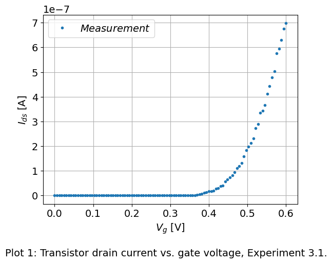

```python
# Load data
import numpy as np
V_g_sweep, Ids = np.load("1_linear_scale_nfet.npy")

# plot in linear scale
import matplotlib.pyplot as plt
plt.rcParams.update({'font.size': 14})
plt.plot(V_g_sweep, Ids, '.', label = "$Measurement$")
plt.legend()
plt.xlabel("$V_g$ [V]")
plt.ylabel("$I_{ds}$ [A]")
caption="Plot 1: Transistor drain current vs. gate voltage, Experiment 3.1."
plt.figtext(0.5, -0.1, caption, wrap=True, horizontalalignment='center', fontsize=14)
plt.grid()

plt.show()
```

```python
# if it looks nice in the plot, save it!

#plt.savefig("1_linear_scale_nfet.jpg")

# Store data
#data = [V_g_sweep, Ids]

#np.save("1_linear_scale_nfet", data)
```

[output not shown]

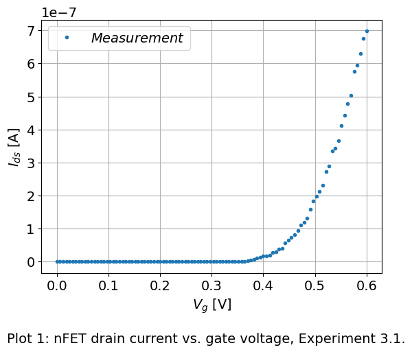

```python
# Load data you saved and plot, to check if the data is saved correctly
V_g_sweep, Ids = np.load("1_linear_scale_nfet.npy")

print("Verifying data saving.")

import matplotlib.pyplot as plt
plt.rcParams.update({'font.size': 14})
plt.plot(V_g_sweep, Ids, '.', label = "$Measurement$")
plt.legend()
plt.xlabel("$V_g$ [V]")
plt.ylabel("$I_{ds}$ [A]")
caption="Plot 1: nFET drain current vs. gate voltage, Experiment 3.1."
plt.figtext(0.5, -0.1, caption, wrap=True, horizontalalignment='center', fontsize=14)
plt.grid()
plt.show()
```

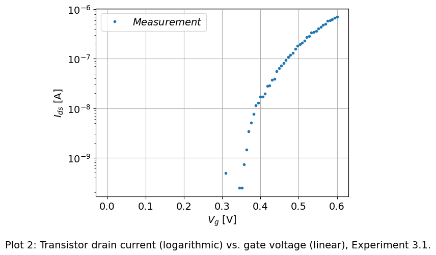

```python
# plot in logarithmic scale
plt.rcParams.update({'font.size': 14})
plt.semilogy(V_g_sweep, Ids,'.', label = "$Measurement$")
plt.legend()
plt.xlabel("$V_g$ [V]")
plt.ylabel("$I_{ds}$ [A]")
caption="Plot 2: Transistor drain current (logarithmic) vs. gate voltage (linear), Experiment 3.1."
plt.figtext(0.5, -0.1, caption, wrap=True, horizontalalignment='center', fontsize=14)
plt.grid()
plt.show()
```

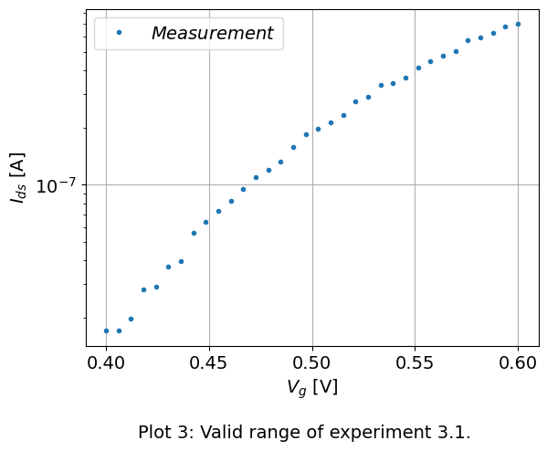

```python
# extract the valid range and plot in logarithmic scale
lower_boundary = 66
V_g_sweep_valid = V_g_sweep[lower_boundary:]
Ids_valid = Ids[lower_boundary:]

# plot in logarithmic scale
plt.rcParams.update({'font.size': 14})
plt.semilogy(V_g_sweep_valid, Ids_valid, '.', label = "$Measurement$")
plt.legend()
plt.xlabel("$V_g$ [V]")
plt.ylabel("$I_{ds}$ [A]")
caption="Plot 3: Valid range of experiment 3.1."
plt.figtext(0.5, -0.1, caption, wrap=True, horizontalalignment='center', fontsize=14)
plt.grid()
plt.show()
```

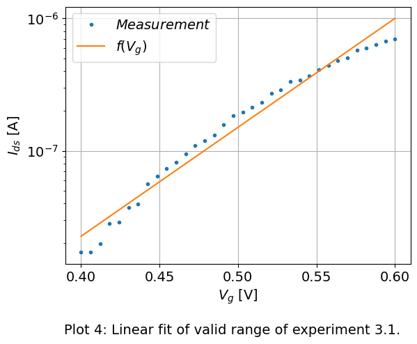

```python
# fit in the valid range (you may want to add the fitted line in the plot)

# We want to fit a linear function m*x + b
m, b = np.polyfit(V_g_sweep_valid, np.log(Ids_valid), 1)

# Create a lambda function for the fit
f = lambda v : np.exp(m*v + b)


# Get y
y = f(V_g_sweep_valid)

# plot in logarithmic scale
plt.rcParams.update({'font.size': 14})
plt.semilogy(V_g_sweep_valid, Ids_valid, '.', label = "$Measurement$")
plt.semilogy(V_g_sweep_valid, y, label = "$f(V_g)$")
plt.legend()
plt.xlabel("$V_g$ [V]")
plt.ylabel("$I_{ds}$ [A]")
caption="Plot 4: Linear fit of valid range of experiment 3.1."
plt.figtext(0.5, -0.1, caption, wrap=True, horizontalalignment='center', fontsize=14)
plt.grid()
plt.show()
```

```python
print(f"We made a linear fit for the valid range using f(V_g)={m} * V_g - {abs(b)}")
```

```
We made a linear fit for the valid range using f(V_g)=18.94646428890323 * V_g - 25.18393671613221
```

- Extract $I_0$ and $\kappa$

```python
# I_0
I_0 = f(0)
print("I_0 = ", I_0, "A")
```

```
I_0 =  1.1554608940006338e-11 A
```

```python
# kappa
print("kappa = ", m*26e-3)
```

```
kappa =  0.49260807151148395
```

- Extract the threshold voltage and the current at threshold, using the definition given

in class: $I_{ds}$ is half of the extrapolated subthreshold current.

```python
# compute threshold voltage
from scipy import interpolate
g = interpolate.interp1d(V_g_sweep, Ids)


eps = 0.2
start = 0.4
stop = 0.6
N_max = 100
x = np.linspace(start, stop, N_max)

for j, V_g_vary in enumerate(x):
    frac = f(V_g_vary) / g(V_g_vary)
    #print(j, frac, V_g_vary)
    if (2 - frac) < eps:
        #print(frac, V_g_vary)
        break


print(f"The threshold voltage is V_g={V_g_vary} V. However the voltage sweep we did was not optimal, as the upper \
bound was too low. We chose an upper bound of 0.6 V, which is why we get this threshold voltage. We  can see this \
from the fact that the fraction of the interpolated function and the linear fit is only 1.432 i.e. its not close \
to 2.")
```

[output not shown]

```python
# compute Ids at threshold voltage
#I_interp = interpolate.interp1d(, ...)
#I_interp(...)

# The sub exercise asked for the Ids at threshold voltage which is given by the real data i.e. the measurements
# done in the experiment. This is why we don't use the fitted function.
print(f"The current at threshold voltage V_g={V_g_vary} V is {g(V_g_vary)} A")
```

[output not shown]

## 3.2 P-FET

```python
# uses schemdraw, you may have to install it in order to run it on your PC
import schemdraw
import schemdraw.elements as elm
d = schemdraw.Drawing()
Q = d.add(elm.PFet, reverse=True, bulk=True)
d.add(elm.Dot, xy=Q.gate, lftlabel='gate=AIN0')
d.add(elm.Dot, xy=Q.bulk, rgtlabel='bulk=AIN1')
d.add(elm.Dot, xy=Q.drain, botlabel='drain=GO21')
d.add(elm.Dot, xy=Q.source, toplabel='source=GO23')
d.draw()
```

Hint: To cancel out the leakage current and shunt resistance, you may want to do a subtraction:

$I_{ds} = I_{GO21} - I_{GO21}|_{V_g = 0}$

- You have to choose the input voltage demultiplexer by sending a configuration event (make sure LED1 blinks):

```python
events = [pyplane.Coach.generate_aerc_event( \
    pyplane.Coach.CurrentOutputSelect.SelectLine5, \
    pyplane.Coach.VoltageOutputSelect.NoneSelected, \
    pyplane.Coach.VoltageInputSelect.SelectLine1, \
    pyplane.Coach.SynapseSelect.NoneSelected, 0)]

p.send_coach_events(events)
```

**Make sure the chip receives the event by a blink of LED1, if it's not the case, the chip is dead and you must replug it.**

- What will be the fixed source, bulk (substrate or well), and drain voltages?

```python
# set bulk voltage
vb_p = 1.8
p.set_voltage(pyplane.DacChannel.AIN1, vb_p)
print("The bulk voltage is set to {} V".format(vb_p))
```

```
The bulk voltage is set to 1.8 V
```

```python
# set source voltage
vs_p = 1.8
p.set_voltage(pyplane.DacChannel.GO23, vs_p)
print("The source voltage is set to {} V".format(vs_p))
```

```
The source voltage is set to 1.8 V
```

```python
# set drain voltage
vd_p = 0.0
p.set_voltage(pyplane.DacChannel.GO21, vd_p)
print("The drain voltage is set to {} V".format(vd_p))
```

```
The drain voltage is set to 0.0 V
```

```python
# set trial gate voltage
vg_p = 1.5
p.set_voltage(pyplane.DacChannel.AIN0, vg_p)
print("The gate voltage is set to {} V".format(vg_p))
```

```
The gate voltage is set to 1.5 V
```

```python
# read Ids
ids_p = p.read_current(pyplane.AdcChannel.GO23)
print("Ids is {} A".format(ids_p))
```

```
Ids is 7.592772988118668e-08 A
```

- Data aquisition

```python
# sweep gate voltage
vg_p = 1.8
p.set_voltage(pyplane.DacChannel.AIN0, vg_p)
I_leakage_p = p.read_current(pyplane.AdcChannel.GO23)

# Number of steps
N = 100
Ids_p = []

# Sweeping values
V_g_sweep_p = np.linspace(1.0, 1.8, N)

for V_g in V_g_sweep_p:
    # Set gate voltage
    p.set_voltage(pyplane.DacChannel.AIN0, V_g)
    # Read current
    I = p.read_current(pyplane.AdcChannel.GO23)

    # Append to end of list
    Ids_p.append(I - I_leakage_p)
```

```python
# Load data
V_g_sweep_p, Ids_p = np.load("3.2_V_g_sweep.npy")
```

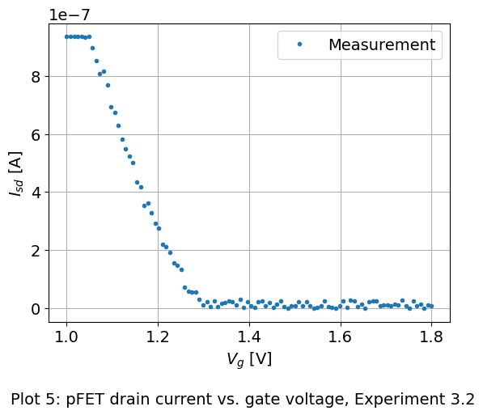

```python
# plot in linear scale
plt.plot(V_g_sweep_p, Ids_p, '.', label="Measurement")
plt.legend()
plt.xlabel("$V_g$ [V]")
plt.ylabel("$I_{sd}$ [A]")
caption="Plot 5: pFET drain current vs. gate voltage, Experiment 3.2"
plt.figtext(0.5, -0.1, caption, wrap=True, horizontalalignment='center', fontsize=14)
plt.grid()
plt.show()

# Save the data
#data = [V_g_sweep_p, Ids_p]
#np.save("3.2_V_g_sweep", data)
```

```python
# if it looks nice in the plot, save it!
plt.savefig("2_linear_scale_pfet.jpg")
```

[output not shown]

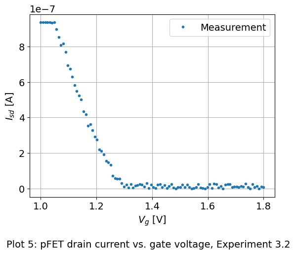

```python
# Load data you saved and plot, to check if the data is saved correctly
# Load data
V_g_sweep_p, Ids_p = np.load("3.2_V_g_sweep.npy")

print("Verifying data saving.")

# plot in linear scale
plt.plot(V_g_sweep_p, Ids_p, '.', label="Measurement")
plt.legend()
plt.xlabel("$V_g$ [V]")
plt.ylabel("$I_{sd}$ [A]")
caption="Plot 5: pFET drain current vs. gate voltage, Experiment 3.2"
plt.figtext(0.5, -0.1, caption, wrap=True, horizontalalignment='center', fontsize=14)
plt.grid()
plt.show()
```

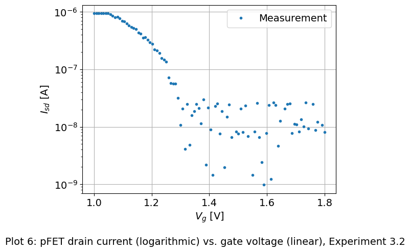

```
After about 1.3 V the measurements become noisy. That region is not of our interest, because it corresponds to a zone where measurements become domianted by device noise (which results in a negligible current).
```

```python
# plot in logarithmic scale
plt.semilogy(V_g_sweep_p, Ids_p, '.', label="Measurement")
plt.legend()
plt.xlabel("$V_g$ [V]")
plt.ylabel("$I_{sd}$ [A]")
caption="Plot 6: pFET drain current (logarithmic) vs. gate voltage (linear), Experiment 3.2"
plt.figtext(0.5, -0.1, caption, wrap=True, horizontalalignment='center', fontsize=14)
plt.grid()
plt.show()

print("After about 1.3 V the measurements become noisy. That region is not of our interest, because it \
corresponds to a zone where measurements become domianted by device noise (which results in a negligible current).")
```

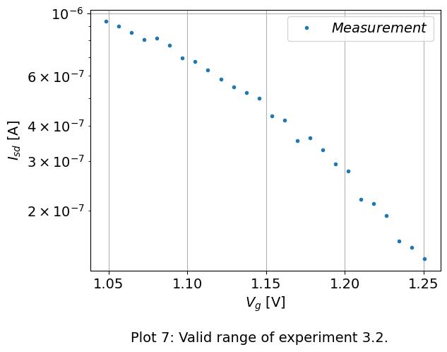

```python
# extract the valid range and plot in logarithmic scale
low = 6
up = 32
V_g_sweep_valid = V_g_sweep_p[low:up]
Ids_valid = Ids_p[low:up]

# plot in logarithmic scale
plt.rcParams.update({'font.size': 14})
plt.semilogy(V_g_sweep_valid, Ids_valid, '.', label = "$Measurement$")
plt.legend()
plt.xlabel("$V_g$ [V]")
plt.ylabel("$I_{sd}$ [A]")
caption="Plot 7: Valid range of experiment 3.2."
plt.figtext(0.5, -0.1, caption, wrap=True, horizontalalignment='center', fontsize=14)
plt.grid()
plt.show()
```

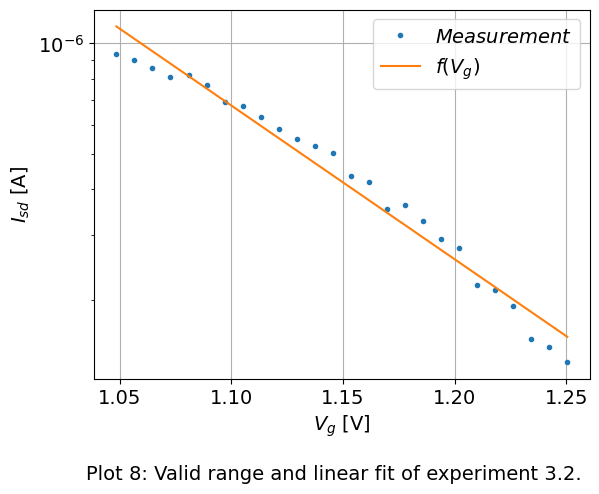

```python
# fit in the valid range (you may want to add the fitted line in the plot)

# We want to fit a linear function m*x + b
m, b = np.polyfit(V_g_sweep_valid, np.log(Ids_valid), 1)

# Create a lambda function for the fit
f = lambda v : np.exp(m*v + b)


# Get y
y = f(V_g_sweep_valid)

# plot in logarithmic scale
plt.rcParams.update({'font.size': 14})
plt.semilogy(V_g_sweep_valid, Ids_valid, '.', label = "$Measurement$")
plt.semilogy(V_g_sweep_valid, y, label = "$f(V_g)$")
plt.legend()
plt.xlabel("$V_g$ [V]")
plt.ylabel("$I_{sd}$ [A]")
caption="Plot 8: Valid range and linear fit of experiment 3.2."
plt.figtext(0.5, -0.1, caption, wrap=True, horizontalalignment='center', fontsize=14)
plt.grid()
plt.show()
```

```python
print(f"We made a linear fit for the valid range using f(V_g)={m} * V_g - {abs(b)}")
```

```
We made a linear fit for the valid range using f(V_g)=-9.644906113230464 * V_g - 3.5978516919080943
```

Extract $I_0$ and $\kappa$

```python
# I_0
vs_p = 1.8 # set because we can't set it above anymore because we don't have the device
I_0 = f(0.0)/np.exp(vs_p)
print("I_0 = ", I_0, "A")
```

```
I_0 =  0.004526294379991681 A
```

```python
# kappa
thermal_voltage = 26e-3
print("kappa = ", abs(m)*thermal_voltage)
```

```
kappa =  0.25076755894399205
```

Extract the threshold voltage and the current at threshold, using the definition given in class: $I_{ds}$ is half of the extrapolated subthreshold current.

```python
# compute threshold voltage
from scipy import interpolate
g = interpolate.interp1d(V_g_sweep_p, Ids_p)


eps = 0.2
start = 1.0
stop = 1.2
N_max = 100
x = np.linspace(start, stop, N_max)

for j, V_g_vary in enumerate(x):
    frac = f(V_g_vary) / g(V_g_vary)
    #print(j, frac, V_g_vary)
    if (2 - frac) < eps:
        print(frac, V_g_vary)
        break

print(f"The threshold voltage is V_g={V_g_vary} V. We  can see that the fraction of the interpolated function \
and the linear fit is 1.896 which is close to 2 and which indicates that the computed threshold voltage is coherent.")
```

```
1.8962890496971807 1.0
The threshold voltage is V_g=1.0 V. We  can see that the fraction of the interpolated function and the linear fit is 1.896 which is close to 2 and which indicates that the computed threshold voltage is coherent.
```

```python
# compute Ids at threshold voltage
#I_interp = interpolate.interp1d(..., ...)
g(V_g_vary)

print(f"The threshold current is {g(V_g_vary)} A")
```

```
The threshold current is 9.35058587003823e-07 A
```

# 4 Back Gate Effect

In this experiment, we will characterize the relationship between the gate and source voltages for both the N-FET and the P-FET devices when the channel current is held constant. This experiment shows convincingly the relative effectiveness of each terminal and provides a direct measurement of $\kappa$.

Hint: Because we cannot read the voltage of the GO pins, it is not possible to simply keep $I_{ds}$ fixed and read $V_s$. In order to do so, we have to use some searching algorithm (e.g. binary search) to find the corresponding $V_s$.

## 4.1 N-FET

- If you are not coming from 3.1 directly, you have to set the input voltage demultiplexer by sending a configuration event (make sure LED1 blinks):

**Make sure the chip receives the event by a blink of LED1, if it's not the case, the chip is dead and you must replug it.**

- set fixed voltages

```python
# set drain voltage
vd_n = 1.0
p.set_voltage(pyplane.DacChannel.GO22, vd_n)
print("The drain voltage is set to {} V".format(vd_n))
```

```
The drain voltage is set to 1.0 V
```

```python
# set trial gate voltage
v_g = 0.5
p.set_voltage(pyplane.DacChannel.AIN0, v_g)
print("The gate voltage is set to {} V".format(v_g))

# set source voltae
v_s = 0.0
p.set_voltage(pyplane.DacChannel.GO20, v_s)
print("The source voltage is set to {} V".format(v_s))
```

```
The gate voltage is set to 0.5 V
The source voltage is set to 0.0 V
```

```python
# read trial Ids
ids_n = p.read_current(pyplane.AdcChannel.GO20_N)
print("Ids is {} A".format(ids_n))
```

```
Ids is 1.8383788358278252e-07 A
```

- Data aquisition

```python
# define constants
Vdd = 1.8
max_iter = 10
N_samples = 10
```

What Ids target should you set? And what is the corresponding Vg? Hint: Refer to 3.1

```python
Ids_target = ids_n
#Vg_target =
```

```python
# initialize variables

import numpy as np
import time

start = 0.4
stop = 1.0
Vg = np.arange(start, stop, (stop - start) / N_samples)
Vs = np.ones(N_samples) * Vdd/2
print(Vg)
```

```
[0.4  0.46 0.52 0.58 0.64 0.7  0.76 0.82 0.88 0.94]
```

```python
# sweep Vg
for n in range(N_samples):

    Vstep = Vdd/4

    # set Vg
    p.set_voltage(pyplane.DacChannel.AIN0, Vg[n])

    # search for Vs that gives Ids_target
    for j in range(max_iter):

        # set Vs
        p.set_voltage(pyplane.DacChannel.GO20, Vs[n])

        # wait to settle
        time.sleep(0.1)

        # read Ids and compute its difference with the target
        dI = p.read_current(pyplane.AdcChannel.GO20_N) - Ids_target

        # check for convergence
        if np.abs(dI) < Ids_target * 0.1:
            break

        # update Vs and step
        Vs[n] = Vs[n] + Vstep * np.sign(dI)
        Vstep = Vstep/2
```

[output not shown]

[output cut: 22 more lines]

[output not shown]

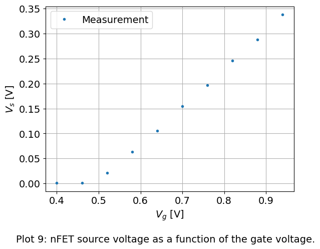

```python
Vg, Vs = np.load("4.1_vg_vs_array.npy")

# plot
# if it looks nice in the plot, save it!
plt.plot(Vg, Vs, '.', label = "Measurement")
plt.legend()
plt.xlabel("$V_g$ [V]")
plt.ylabel("$V_s}$ [V]")
caption="Plot 9: nFET source voltage as a function of the gate voltage."
plt.figtext(0.5, -0.1, caption, wrap=True, horizontalalignment='center', fontsize=14)
plt.savefig("4.1_vg_vs.jpg")
plt.grid()
plt.show()

#data = [Vg, Vs]
#np.save("4.1_vg_vs_array", data)
```

```python
# if it looks nice in the plot, save it!
# already did above
```

- How do you compute $\kappa$? Does it stay constant for different $V_g$?

```python
# calculate kappa
# We want to fit a linear function m*x + b
m, b = np.polyfit(Vg[2:], Vs[2:], 1)

# Kappa is given by dVs/dVg. So we fit a linear  function and read its slope.
print(f"kappa = {m}")
print(f"kappa stays constant for different Vg, as the Vs(Vg) plot is linear and has a constant slope.")
```

```
kappa = 0.7547433035714287
kappa stays constant for different Vg, as the Vs(Vg) plot is linear and has a constant slope.
```

## 4.2 P-FET

- If you are not coming from 3.2 directly, you have to set the input voltage demultiplexer by sending a configuration event (make sure LED1 blinks):

**Make sure the chip receives the event by a blink of LED1, if it's not the case, the chip is dead and you must replug it.**

- set fixed voltages

```python
# set bulk voltage
vb_p = 1.8
p.set_voltage(pyplane.DacChannel.AIN1, vb_p)
print("The bulk voltage is set to {} V".format(vb_p))
```

```
The bulk voltage is set to 1.8 V
```

```python
# set source voltage
vs_p = 1.8
p.set_voltage(pyplane.DacChannel.GO23, vs_p)
print("The source voltage is set to {} V".format(vs_p))
```

```
The source voltage is set to 1.8 V
```

```python
# set drain voltage
vd_p = 0.0
p.set_voltage(pyplane.DacChannel.GO21, vd_p)
print("The drain voltage is set to {} V".format(vd_p))
```

```
The drain voltage is set to 0.0 V
```

```python
# read Ids
ids_p = p.read_current(pyplane.AdcChannel.GO23)
print("Ids is {} A".format(ids_p))
```

```
Ids is 9.99023427539214e-07 A
```

- Data aquisition

```python
# define constants
Vdd = 1.8
max_iter = 10
N_samples = 10
```

What Ids target should you set? And what is the corresponding Vg? Hint: Refer to 3.2

```python
Ids_target = 1.3e-7
#Vg_target =
```

```python
# initialize variables

import numpy as np
import time

start = 1.1
stop = 1.8
Vg_p = np.arange(start, stop, (stop - start) / N_samples)

h = 5
Vg_p[0:h] = np.linspace(start, start*1.2, 5 )
Vg_p[h:N_samples] = np.linspace(start*1.3, stop, 5)

print(Vg_p)

Vs_p = np.ones(N_samples) * Vdd/2
```

```
[1.1    1.155  1.21   1.265  1.32   1.43   1.5225 1.615  1.7075 1.8   ]
```

```python
# Load the data
Vg_p, Vs_p = np.load("4.2_vg_vs.npy")
```

```python
# sweep Vg
for n in range(N_samples):

    Vstep = Vdd/4

    # set Vg
    p.set_voltage(pyplane.DacChannel.AIN0, Vg_p[n])

    # search for Vs that gives Ids_target
    for j in range(max_iter):

        # set Vs
        p.set_voltage(pyplane.DacChannel.GO23, Vs_p[n])

        # wait to settle
        time.sleep(0.1)

        # read Ids and compute its difference with the target
        dI = p.read_current(pyplane.AdcChannel.GO23) - Ids_target

        # check for convergence
        print(np.abs(dI))
        if np.abs(dI) < Ids_target * 0.05:
            break

        # update Vs and step
        Vs_p[n] = Vs_p[n] - Vstep * np.sign(dI)
        Vstep = Vstep/2
        # Why did we chose a minus sign? Let's imagine dI > 0. In order to reach target current, the current should
        # be decreased. To decrease I_ds, the driving voltage (Vg - Vs) should be increased, which means
        # Vs should be decreased. That is why there is a minus sign.
```

[output not shown]

[output cut: 37 more lines]

[output not shown]

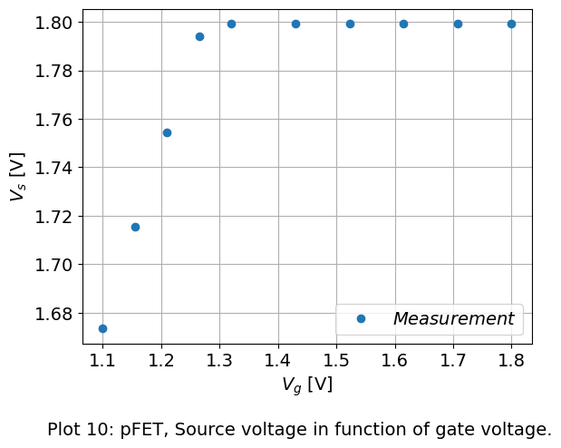

```python
# plot
plt.rcParams.update({'font.size': 14})
plt.plot(Vg_p, Vs_p, 'o', label = "$Measurement$")
plt.legend()
plt.xlabel("$V_g$ [V]")
plt.ylabel("$V_s$ [V]")
caption="Plot 10: pFET, Source voltage in function of gate voltage."
plt.figtext(0.5, -0.1, caption, wrap=True, horizontalalignment='center', fontsize=14)
plt.grid()
plt.show()
```

```python
# if it looks nice in the plot, save it!
plt.savefig("4.2_vg_vs.jpg")
```

- How do you compute $\kappa$? Does it stay constant for different $V_g$?

```python
# calculate kappa
# calculate kappa
# We want to fit a linear function m*x + b
m, b = np.polyfit(Vg_p, Vs_p, 1)

print(f"kappa = {m}. Which seems plausible since 0 < {m} < 1.0. For the same reasons specified in 4.1 \
kappa stays constant for different Vg in the subthreshold region.")
```

[output not shown]

# 5. Clean up

- Close you device and release memory by doing

```python
del p
```

- Save your changes
- Close jupyter notebook properly (`File -> Close and Halt`)
- Save the files you need for the report to your own PC

# 6. Postlab

*The answers to the postlab should be included below.*

For the following questions assume an *n*-well process with the transistor in saturation.

Many differences in the properties of native and well transistors arise from the fact that the well is usually more heavily doped than the substrate. That was certainly true in the past when people were using a single well process. Today, most processes are double-well or *twin-tub* both n- and p-wells are implanted in a lightly doped epitaxially-grown p-substrate.  
*Epitaxially* means that the layer is grown atom by atom by chemical vapor deposition, resulting in a very regular and pure crystal structure.

The classchips you are using were fabricated in a 0.18 $\mu$m process. For an *n*-well device, the *n*-type material of the well is the bulk, while the active areas (source and drain) are *p*-type. The gate voltage must force all the electrons in the *n*-well away from the surface. The resulting depletion region provides a channel for holes through enemy territory (n-well) separating the p-type source and drain. If the bulk is heavily doped, the gate must work harder to repel electrons.

Another way of saying this is that the capacitance of this depletion layer and the gate oxide capacitance form a *capacitive divider* that determines how much of the gate voltage appears at the surface channel. If the depletion layer is thin, the depletion capacitance will be large and hence the divider ratio will be unfavorable.

**(1)** How does the thickness of the depletion region depend on the doping and on the channel (surface) potential? Assume that the doping density is uniform.

**Answer:** On slide 55 we can see $\Psi_s$ plottet against $V_g$. We see that $\kappa$ decreases as $\Psi_s$ grows.

In Slide 52 we find $\kappa = \frac{\partial \Psi_s}{\partial V_g} = \frac{C_{ox}}{C_{ox} + C_{dep}}$

Furthermore $C = \frac{dQ}{dV}$ and since $Q$ depends on the geometry we conclude that $C_{dep}$ depends on the geometry and is proportional to it.

Thus we can conclude that $\Psi_s$ is inverse proportional to the thickness of the depletion region.

**(2)** Explain why $\kappa$ varies with the source voltage at constant current (as in the source follower).

In the group we discussed the experiment and concluded this isn't the case yet I remember that the lecture said something different... so I'm confused.

**(3)** Is there a difference in $\kappa$ between the n- and p-type devices? Explain the reason.

We found two different values in the experiments but I think that's something wrong.

**(4)** From your results in the experiments, state under what conditions the assumption that $\kappa$ is constant is reasonable.

$\kappa$ should be constnat in the subthreshold regime. But again, I'm very confused about this topic